# Investments

Week 1 – Complete Portfolio in R  
Utz Weitzel – VU Finance

> This is bonus material in the course, which may be useful for your thesis project or other data-related work. The code below introduces Monte Carlo simulation, which is widely used in practice and research, for example for portfolio optimization, simulating possible price and return paths, and option pricing. So, although this material is not relevant for the exam, it may still be worthwhile to study the code.

# Prepare session

In RStudio, open a project, or make a new one.

**Clear the console**

Click on the broom icon (upper right corner of console), or type

```r
cat("\014")
```

**Clear the environment**

Click on the broom icon (upper right corner of environment), or type

```r
rm(list = ls(all.names = TRUE))
```

**Load the Tidyverse package**

```r
if(!require(tidyverse)) install.packages("tidyverse")
library(tidyverse)
options(dplyr.summarise.inform = FALSE)
```

# Prepare data

Import the file `df102.csv` for monthly stock and tbill returns (download the file from Canvas into your project folder first)

```r
df102 = read_csv("df102.csv", show_col_types=FALSE)
```

Let’s compute excess returns and then pivot the file from a long format to a wide format so that each stock has its own column with excess returns.

```r
df103 = df102 |>
  mutate(rx = re-tbill) |>
  select(date, ticker, rx) |>
  pivot_wider(names_from = ticker, values_from = rx)
```

We can see that we are dealing with monthly excess returns of 4 stocks: AAPL, KO, MCD, and MSFT.

# Average stock returns

We start with obtaining the average return for each of the four stocks and their variance-covariance matrix.

**Define a matrix of excess stock returns called ‘rx_stocks’**

First, strip the date column, leaving only the monthly excess stock returns.

```r
rx_stocks = df103 |> select(-date) # remove the date column
```

**Calculating average stock returns**

Calculate the mean excess return of each stock for the whole period

```r
rx_mean = colMeans(rx_stocks, na.rm = TRUE)
```

> Note that `rx_mean` is not a dataframe but a numeric vector. You can see this in the environment window, where rx_mean is listed under values.

# Covariance matrix

**Construct the covariance matrix**

For the covariance matrix, we use the option `'pairwise.complete.obs'` as this uses all *complete* pairs of data, skipping over potential missing values

```r
covMatrix = rx_stocks |> cov(use = 'pairwise.complete.obs')

View(covMatrix)
```

# Simulation of weights

> Now we need a bunch of different weight combinations, each of which sums up to 1. How can we compute such combinations? For this we need a Monte Carlo simulation, which is a fancy name for introducing randomness (here: different portfolio weight combinations).

## Monte Carlo Preparation

**Define the parameters**

The initialization of the Monte Carlo simulation of the hypothetical portfolios requires defining parameters.

```r
# Parameters
num_stk = 4 # number of stocks

num_sim = 2000 # number of portfolios to simulate

set.seed(666) # a seed to replicate the randomization (optional)
```

**Initialize empty storage**

Let us initialize an empty data frame to store the results.

Rows = number of simulations.  
Columns = weight in each stock (4 stocks)

```r
dfweights = data.frame(matrix(nrow=num_sim, ncol=num_stk)) # df to save results

colnames(dfweights) = c(colnames(rx_stocks)) # give column names to the four stocks
```

## Monte Carlo Simulation

Ready to go!

We loop over the number of simulations (=2000) and draw 4 random weights each time

**Creating random weights**

```r
# Loop over the number of simulations (here: 2000)
for (i in 1:num_sim) { # for 1, 2, 3, ..., to 2000

  # Obtain random weights
  weights = runif(num_stk)         # draw num_stk (= 4) uniform random numbers
  weights = weights / sum(weights) # make sure the weights sum to one

  # store the weights in the dataframe
  dfweights[i,1] = weights[1]
  dfweights[i,2] = weights[2]
  dfweights[i,3] = weights[3]
  dfweights[i,4] = weights[4]    # num_stk columns for weights
}
```

Let’s check the output

```r
View(dfweights)
```

We have 2000 different weight combinations for the four stocks. In row 1, we invest 0.36 in Apple, 0.09 in Coca Cola, 0.45 in McDonald’s and 0.09 in Microsoft. In rows 2, 3, 4, … etc. we have different weight combinations, each of which sums up to 1 per row. In other words, we have 2000 uniquely different portfolios; every row is a new portfolio.

# Compute Risk + Return

Now we can compute the risk-return profiles for the 2000 simulated portfolios of the four stocks.

**Define the number of portfolios and the weights**

```r
num_portfolios = nrow(dfweights) # 2000 possible portfolios to choose from
```

**Create an empty table to store the portfolio risk and return**

```r
risk_return = data.frame(matrix(nrow=num_portfolios, ncol=3)) # df to save results
colnames(risk_return) = c("ER", "SD", "SR") # attribute some column names
```

**Loop and compute for each portfolio**

Recall what you have learned about matrix algebra.

```r
# Loop over the number of portfolios (here: 2000)
for (i in 1:num_portfolios) { # for portfolio 1, 2, 3, ..., up to 2000

  # Obtain the weights for one portfolio at a time (= per row)
  w = dfweights[i,]
  w = t(w) # make sure the weights are in column-form instead of row-form

  # Calculate the portfolio return and standard deviation
  rx_p = sum(rx_mean * w)               # portfolio exp. return
  sd_p = sqrt(t(w) %*% covMatrix %*% w) # portfolio risk

  # Store the results per row i (= per portfolio)
  risk_return[i,1] = (1+rx_p)^12 -1      # annualize rx (compound)
  risk_return[i,2] = sd_p * sqrt(12)     # annualize sd
  risk_return[i,3] = risk_return[i,1] / risk_return[i,2] # Sharpe ratio
}

View(risk_return)
```

## Plot Efficient Frontier

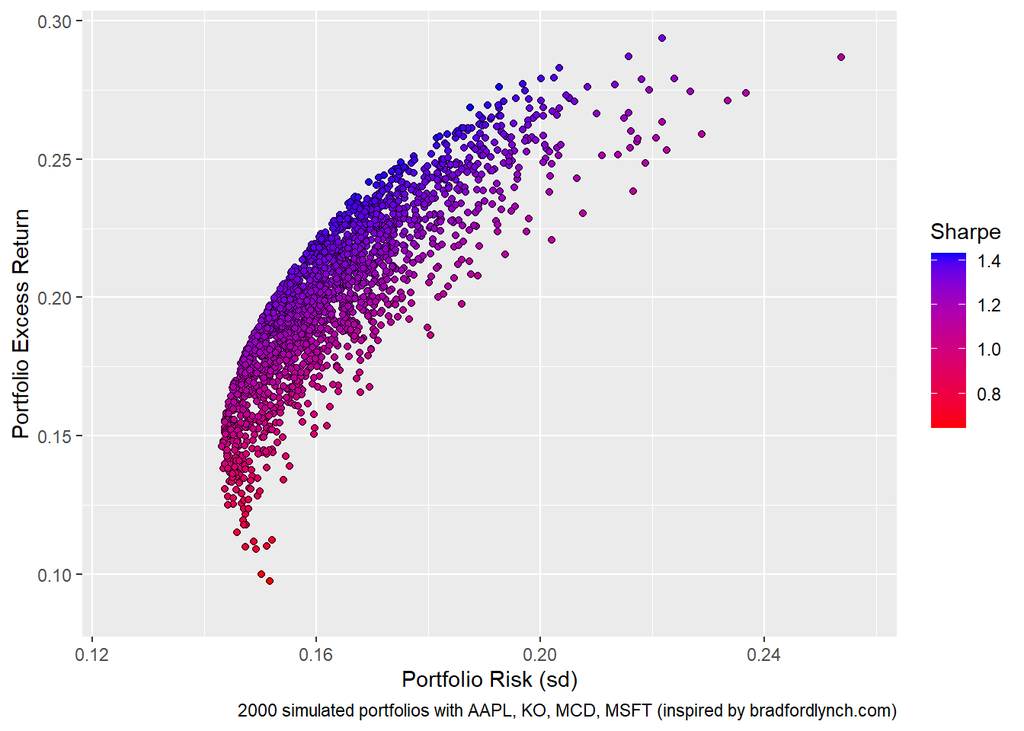

```r
# Plot the resulting portfolio returns and standard deviations
plot_mc = ggplot(risk_return, aes(x = SD, y = ER, fill = SR)) +
  geom_point(shape = 21, color = "black") +
  scale_fill_gradient(low = "red", high = "blue", name = "Sharpe") +
  labs(x = "Portfolio Risk (sd)", y = "Portfolio Excess Return") +
  scale_x_continuous(expand = expansion(add = c(0.025, 0.01))) +
  scale_y_continuous(expand = expansion(add = c(0.02, 0.01)))

plot_mc = plot_mc +
  labs(caption = paste(num_portfolios,
                       "simulated portfolios with",
                       paste(colnames(rx_stocks), collapse = ", "),
                       "(inspired by bradfordlynch.com)"))

print(plot_mc)
```

## Global Minimum Variance

The global minimum variance (GMV) portfolio is the portfolio on the frontier with the *lowest possible risk.*

```r
gmv_p = risk_return |> # global minimum variance portfolio
  mutate(minSD = min(SD)) |>
  filter(minSD == SD) # filter out the row (portfolio) which has the lowest SD
```

View the GMV portfolio

```r
View(gmv_p)
```

## Optimal Risky Portfolio

The optimal portfolio is the portfolio on the frontier with the *maximum Sharpe ratio.*

```r
opt_p = risk_return |> # optimal risky portfolio
  mutate(maxSR = max(SR)) |>
  filter(maxSR == SR) # filter out the row (portfolio) which has the highest SR
```

View the optimal portfolio

```r
View(opt_p)
```

## Plot Optimal Risky

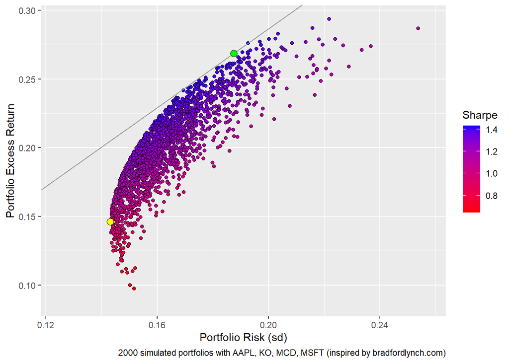

```r
layer_gmv = geom_point(data = gmv_p, aes(x = SD, y = ER),
                       shape = 21, size = 3, fill = "yellow")

layer_opt = geom_point(data = opt_p, aes(x = SD, y = ER),
                       shape = 21, size = 3, fill = "green")

layer_cal = geom_abline(intercept=0, slope=opt_p$SR, color="grey60")

print(plot_mc + layer_gmv + layer_cal + layer_opt)
```

# Complete Portfolio

The optimal *complete* portfolio is a mix between the optimal *risky* portfolio and a risk-free asset. It depends on your level of risk aversion.

If we are risk averse (`A>0`), what is the right mix between the optimal portfolio `opt_p` and any risk-free alternative?

Recall the derived optimal weight y*.

## Case 1: A = 9.5

```r
A_hi = 9.5 # very risk averse

# The optimal share to invest in the risky portfolio
y_star_hi = opt_p$ER / (A_hi*(opt_p$SD^2))

# Calculate portfolio return and risk
ret_hi    = y_star_hi * opt_p$ER + (1 - y_star_hi)*0
rsk_hi    = y_star_hi * opt_p$SD + (1 - y_star_hi)*0

print(paste('Optimal weight in risky portfolio (high risk aversion):', y_star_hi))
```

```
[1] "Optimal weight in risky portfolio (high risk aversion): 0.805283950496433"
```

> We do not need `rf` for the computation of `y_star`, because we are using *excess returns* `ER` (based on `rx`). Also, `ER`and `SD` are annualized values already.

## Case 2: A = 6

```r
A_lo = 6 # less risk averse

# The optimal share to invest in the risky portfolio
y_star_lo = opt_p$ER / (A_lo*(opt_p$SD^2))

# Calculate portfolio return and risk
ret_lo    = y_star_lo * opt_p$ER
rsk_lo    = y_star_lo * opt_p$SD

print(paste('Optimal weight in risky portfolio (lower risk aversion):', y_star_lo))
```

```
[1] "Optimal weight in risky portfolio (lower risk aversion): 1.27503292161935"
```

## Plot Complete Portfolio

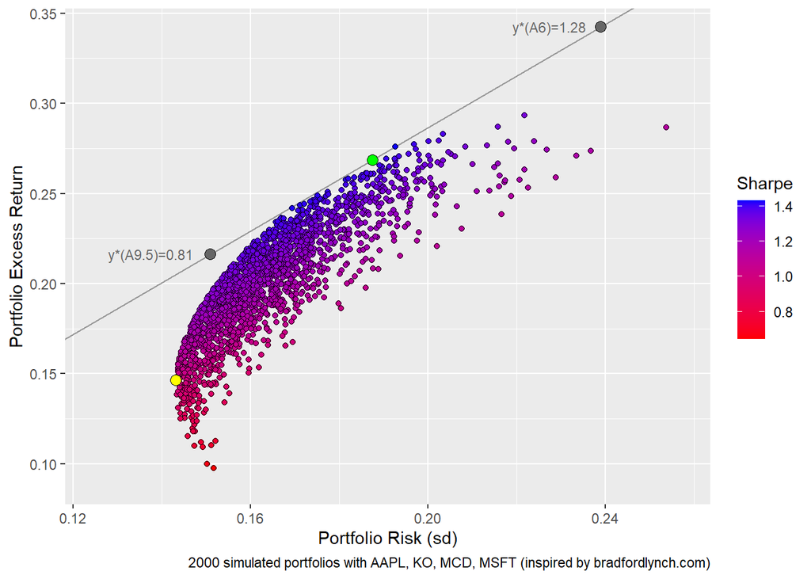

```r
plot_mc2 = ggplot(risk_return, aes(x = SD, y = ER, fill = SR)) +

  # capital allocation line
  geom_abline(intercept = 0, slope = opt_p$SR, color = "grey60") +

  # simulated portfolios
  geom_point(shape = 21, color = "black") +

  # color scale for Sharpe ratio
  scale_fill_gradient(low = "red", high = "blue", name = "Sharpe") +

  # optimal risky portfolio
  geom_point(data = opt_p, aes(x = SD, y = ER),
             shape = 21, size = 3, fill = "green",
             inherit.aes = FALSE) +

  # global minimum variance portfolio
  geom_point(data = gmv_p, aes(x = SD, y = ER),
             shape = 21, size = 3, fill = "yellow",
             inherit.aes = FALSE) +

  # optimal complete portfolios for A = 5 and A = 10
  annotate("point", x = rsk_lo, y = ret_lo, shape = 21, size = 3, fill = "grey40") +
  annotate("point", x = rsk_hi, y = ret_hi, shape = 21, size = 3, fill = "grey40") +

annotate("text", x = rsk_lo, y = ret_lo,
         label = paste0("y*(A", A_lo, ")=", round(y_star_lo, 2)),
         vjust = 0.5, hjust = 1.2, color = "grey40", size = 3) +

annotate("text", x = rsk_hi, y = ret_hi,
         label = paste0("y*(A", A_hi, ")=", round(y_star_hi, 2)),
         vjust = 0.5, hjust = 1.2, color = "grey40", size = 3) +

  # axes
  scale_x_continuous(expand = expansion(add = c(0.025, 0.01))) +
  scale_y_continuous(expand = expansion(add = c(0.02, 0.01))) +

  # labels
  labs(
    x = "Portfolio Risk (sd)",
    y = "Portfolio Excess Return",
    caption = paste(num_portfolios, "simulated portfolios with",
      paste(colnames(rx_stocks), collapse = ", "),
      "(inspired by bradfordlynch.com)"
    )
  )

print(plot_mc2)
```